# Gene Expression-Based Biomarker Discovery and Machine Learning Analysis of Glioblastoma

### 6.2.2 Top differentially expressed genes

Top upregulated genes

| X | logFC | AveExpr | t | P.Value | adj.P.Val | B | GeneSymbol | EntrezID |
| --- | --- | --- | --- | --- | --- | --- | --- | --- |
| 201291_s_at | 6.420652 | 7.575756 | 13.604702 | 0 | 0e+00 | 45.382904 | TOP2A | 7153 |
| 201292_at | 5.939052 | 8.425525 | 14.411382 | 0 | 0e+00 | 49.169498 | TOP2A | 7153 |
| 219918_s_at | 5.208889 | 7.449718 | 10.954175 | 0 | 0e+00 | 32.478340 | ASPM | 259266 |
| 204162_at | 5.055488 | 6.821915 | 14.891196 | 0 | 0e+00 | 51.384370 | NDC80 | 10403 |
| 202718_at | 4.960416 | 11.249258 | 11.657532 | 0 | 0e+00 | 35.958626 | IGFBP2 | 3485 |
| 201890_at | 4.922372 | 8.638578 | 12.526074 | 0 | 0e+00 | 40.206717 | RRM2 | 6241 |
| 202018_s_at | 4.826627 | 8.066321 | 6.117797 | 0 | 1e-07 | 8.955763 | LTF | 4057 |
| 219978_s_at | 4.442488 | 7.340585 | 11.593141 | 0 | 0e+00 | 35.641316 | NUSAP1 | 51203 |
| 211981_at | 4.420426 | 9.497877 | 9.785697 | 0 | 0e+00 | 26.652143 | COL4A1 | 1282 |
| 210984_x_at | 4.396634 | 8.008475 | 6.522179 | 0 | 0e+00 | 10.783896 | EGFR | 1956 |

Top downregulated genes

| X | logFC | AveExpr | t | P.Value | adj.P.Val | B | GeneSymbol | EntrezID |
| --- | --- | --- | --- | --- | --- | --- | --- | --- |
| 244118_at | -5.585704 | 7.498334 | -8.043002 | 0 | 0 | 18.01253 | GABRA1 | 2554 |
| 242372_s_at | -5.200206 | 5.614363 | -9.968322 | 0 | 0 | 27.56423 | SLC60A1 | 148808 |
| 206384_at | -5.185739 | 6.494915 | -11.421478 | 0 | 0 | 34.79400 | CACNG3 | 10368 |
| 205551_at | -5.108302 | 8.713054 | -8.461543 | 0 | 0 | 20.06765 | SV2B | 9899 |
| 231771_at | -4.983134 | 7.082446 | -7.006199 | 0 | 0 | 13.03204 | GJB6 | 10804 |
| 205827_at | -4.980898 | 8.611417 | -7.831304 | 0 | 0 | 16.98117 | CCK | 885 |
| 230680_at | -4.938713 | 5.547629 | -9.422855 | 0 | 0 | 24.84093 | SLITRK4 | 139065 |
| 203798_s_at | -4.868965 | 9.045651 | -7.578402 | 0 | 0 | 15.75770 | VSNL1 | 7447 |
| 214788_x_at | -4.868916 | 7.122182 | -10.050701 | 0 | 0 | 27.97563 | DDN | 23109 |
| 206456_at | -4.852913 | 7.588745 | -10.056707 | 0 | 0 | 28.00562 | GABRA5 | 2558 |

## 6.3 4.3 Heatmap

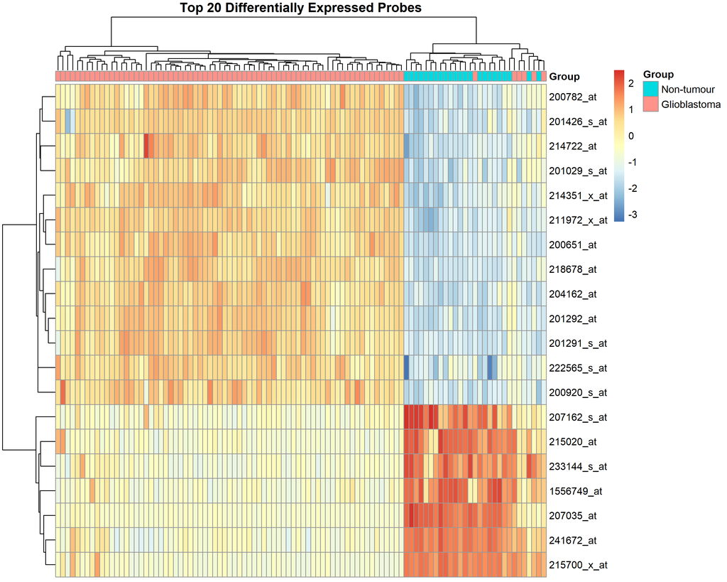

## 6.4 4.4 GO enrichment analysis

The analysis identified 1,001 GO terms for upregulated genes and 631 GO terms for downregulated genes.

### 6.4.1 Upregulated GO terms

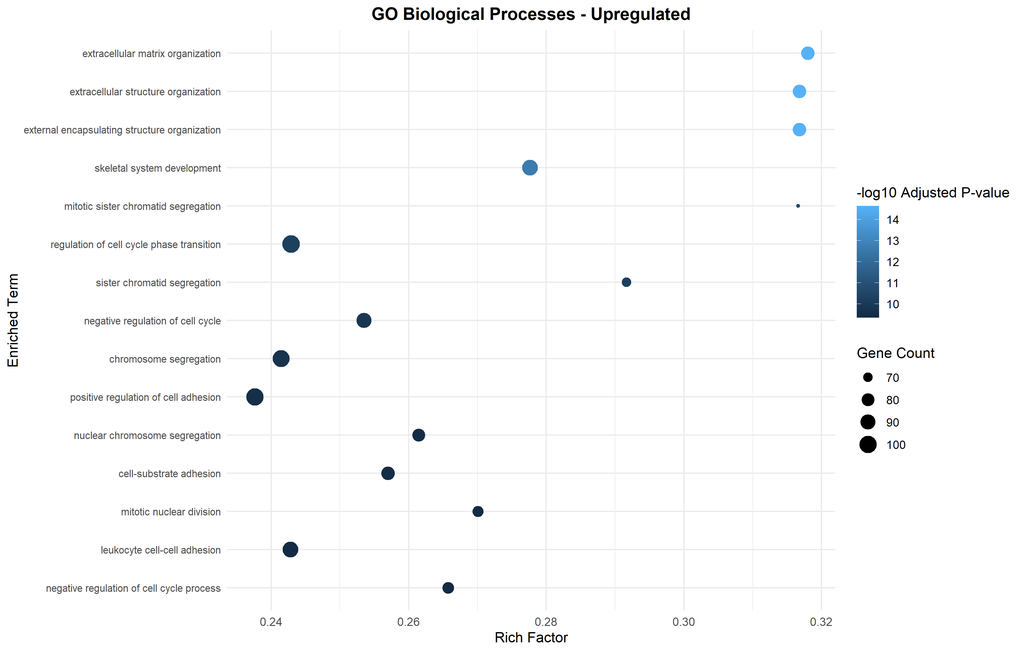

### 6.4.2 Downregulated GO terms

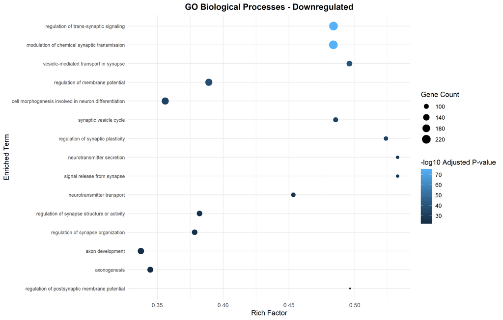

## 6.5 4.5 KEGG pathway enrichment

The analysis identified 58 enriched KEGG pathways for upregulated genes and 71 for downregulated genes.

### 6.5.1 Upregulated pathways

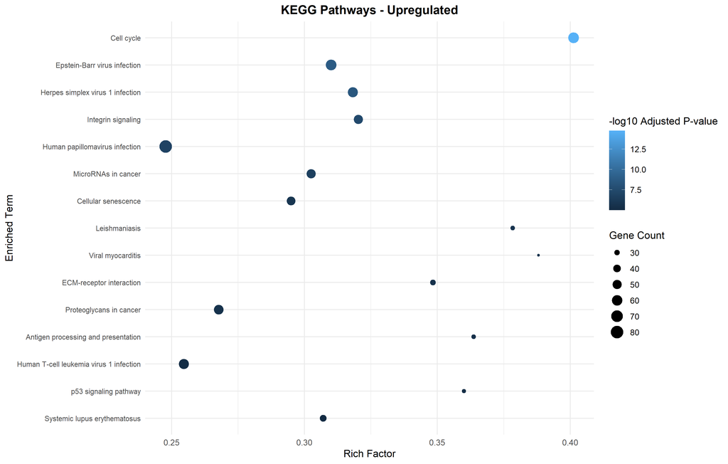

### 6.5.2 Downregulated pathways

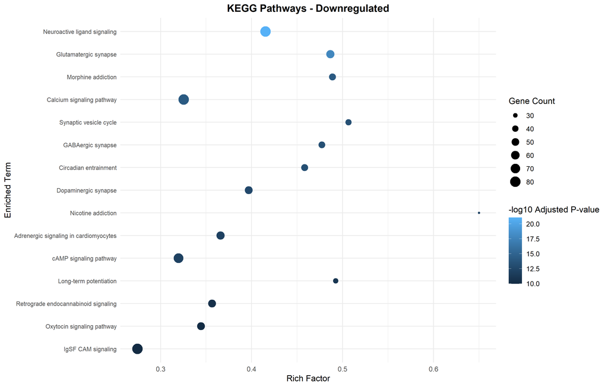

## 6.6 4.6 Machine learning results

Five-fold cross-validation produced the following results:

| Metric | SVM | Random Forest |
| --- | --- | --- |
| Accuracy | 0.92 | 0.91 |
| Sensitivity | 0.9351 | 0.9351 |
| Specificity | 0.8696 | 0.8261 |
| Precision | 0.9600 | 0.9474 |
| F1-score | 0.9474 | 0.9412 |

### 6.6.1 Model comparison

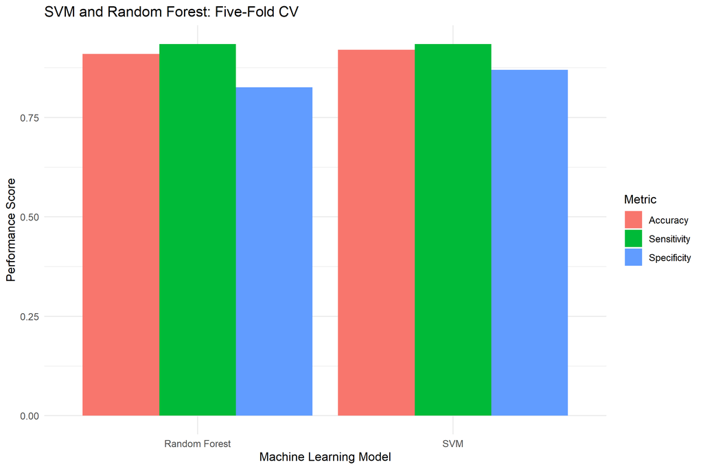

### 6.6.2 Confusion matrix comparison

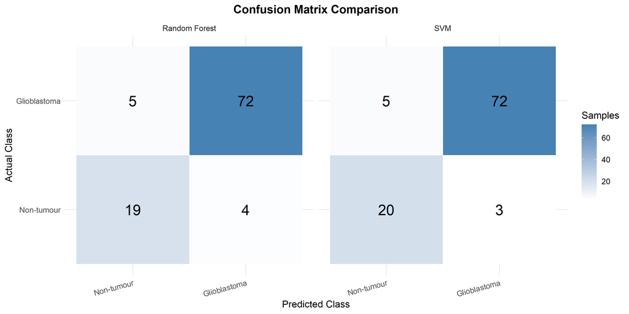

# 7 5. Discussion

The analysis identified several differentially expressed genes between glioblastoma and non-tumour samples. Genes such as TOP2A, ASPM, NDC80 and RRM2 were among the top upregulated results.

GO and KEGG enrichment provided additional information about biological functions and pathways associated with the selected gene lists.

The SVM model achieved a slightly higher cross-validation accuracy than Random Forest. However, the results should be interpreted cautiously because the dataset contains only 100 samples and the groups are imbalanced.

# 8 6. Limitations

1. The dataset contains a relatively small number of samples.
2. The sample groups are imbalanced.
3. The non-tumour group should not automatically be considered healthy controls.
4. No independent external dataset was used for validation.
5. Candidate genes are not clinically validated biomarkers.
6. Machine learning performance may differ on new datasets.

# 9 7. Conclusion and Future Work

This project developed a bioinformatics workflow to analyse glioblastoma gene expression data. Differential expression analysis identified 7,210 significant probe sets. GO and KEGG enrichment analyses provided functional information, while machine learning models achieved cross-validation accuracies of 0.92 for SVM and 0.91 for Random Forest.

Future work should validate the candidate genes using independent datasets, investigate additional machine learning methods and assess model performance on external samples.

# 10 8. Reproducibility

The main R analysis script is located at:

`code/Glioblastoma_Analysis.R`

The generated tables, figures and analysis objects are stored in the `results/` directory.

# 11 9. References

1. Edgar, R., Domrachev, M., and Lash, A. E. (2002). Gene Expression Omnibus: NCBI gene expression and hybridization array data repository. *Nucleic Acids Research*, 30(1), 207–210.
2. GEO Series GSE4290. https://www.ncbi.nlm.nih.gov/geo/query/acc.cgi?acc=GSE4290
3. GEO Platform GPL570. https://www.ncbi.nlm.nih.gov/geo/query/acc.cgi?acc=GPL570
4. Ritchie, M. E., et al. (2015). limma powers differential expression analyses for RNA-sequencing and microarray studies. *Nucleic Acids Research*, 43(7), e47.
5. The Gene Ontology Consortium. (2021). The Gene Ontology resource. *Nucleic Acids Research*, 49(D1), D325–D334.
6. Breiman, L. (2001). Random forests. *Machine Learning*, 45, 5–32.
7. Cortes, C., and Vapnik, V. (1995). Support-vector networks. *Machine Learning*, 20, 273–297.